# Clustering Algorithm for Unupervised Learning - Credit Card Client Anomaly Analysis

Tyler Blakeley, Benjamin Kan, Mohammad Islam, Avijeet Singh

October 29 2018

# 1 Business Understanding

We work at the Retail Credit Risk Analytics department at the Bank of Taiwan. Recently, there have been increasing credit card debt defaults in our bank. Senior Management would like our department to develop a machine learning algorithm to find anomalies in the data that we hope will show early warning signs of default. This will allow the Retail Credit Risk and Collections departments to act early by monitoring these cleints’ credit card limits to find ways to minimize the losses. We would also like to find out which demographics are in the anomaly group which would indicate high susceptiblility of defaults. The Management instructed us to use data from the third parties to build the algorithms as proof-of-concepts before we use our own data. They would also like us to build a user-friendly app to allow them to load in the dataset and identify clients that are in the anomaly group which may indicate high risk of defaulting on their credit card debts.

# 2 Data Understanding

## 2.1 Data Source and Collection

We sourced the third party credit card data from Kaggle (https://www.kaggle.com/uciml/default-of-credit-card-clients-dataset). This dataset contains information on default payments, demographic factors, credit data, history of payment, and bill statements of credit card clients in Taiwan from April 2005 to September 2005. As mentioned above, the goal is to identify a group of customers who exhibit abnormal behaviour comparing with the rest of the data. We assume that abnormal credit behaviour would lead to high default risks. Note that the dataset has already been anonymized to protect the customers’ identities.

## 2.2 Data Description

In the dataset, there are 25 variables:

[output not shown]

## 2.3 Data Exploration

### 2.3.1 Load Packages

```r
#import packages;
library(dplyr)
library(reshape2)
library(ggplot2)
library(Hmisc)
library(corrplot)
library(mice)
library(VIM)
library(pROC)
library(caret)
library(corrgram)
library(GGally)
library(ggthemes)
library(DMwR)
library(gridExtra)
library(rattle)
library(readxl)
library(cluster)
library(sqldf)
library(knitr)
```

### 2.3.2 Load Datasets

Now that the packages are loaded, we can load in the dataset. Note that we converted the dataset file from the Excel to csv format.

```r
data <- read.csv("default of credit card clients.csv", header = TRUE, na= 'NA')
```

Now lets look at the structure and summary of the data.

```r
str(data)
```

```
## 'data.frame':    30000 obs. of  25 variables:
##  $ ï..ID                     : int  1 2 3 4 5 6 7 8 9 10 ...
##  $ LIMIT_BAL                 : int  20000 120000 90000 50000 50000 50000 500000 100000 140000 20000 ...
##  $ SEX                       : int  2 2 2 2 1 1 1 2 2 1 ...
##  $ EDUCATION                 : int  2 2 2 2 2 1 1 2 3 3 ...
##  $ MARRIAGE                  : int  1 2 2 1 1 2 2 2 1 2 ...
##  $ AGE                       : int  24 26 34 37 57 37 29 23 28 35 ...
##  $ PAY_0                     : int  2 -1 0 0 -1 0 0 0 0 -2 ...
##  $ PAY_2                     : int  2 2 0 0 0 0 0 -1 0 -2 ...
##  $ PAY_3                     : int  -1 0 0 0 -1 0 0 -1 2 -2 ...
##  $ PAY_4                     : int  -1 0 0 0 0 0 0 0 0 -2 ...
##  $ PAY_5                     : int  -2 0 0 0 0 0 0 0 0 -1 ...
##  $ PAY_6                     : int  -2 2 0 0 0 0 0 -1 0 -1 ...
##  $ BILL_AMT1                 : int  3913 2682 29239 46990 8617 64400 367965 11876 11285 0 ...
##  $ BILL_AMT2                 : int  3102 1725 14027 48233 5670 57069 412023 380 14096 0 ...
##  $ BILL_AMT3                 : int  689 2682 13559 49291 35835 57608 445007 601 12108 0 ...
##  $ BILL_AMT4                 : int  0 3272 14331 28314 20940 19394 542653 221 12211 0 ...
##  $ BILL_AMT5                 : int  0 3455 14948 28959 19146 19619 483003 -159 11793 13007 ...
##  $ BILL_AMT6                 : int  0 3261 15549 29547 19131 20024 473944 567 3719 13912 ...
##  $ PAY_AMT1                  : int  0 0 1518 2000 2000 2500 55000 380 3329 0 ...
##  $ PAY_AMT2                  : int  689 1000 1500 2019 36681 1815 40000 601 0 0 ...
##  $ PAY_AMT3                  : int  0 1000 1000 1200 10000 657 38000 0 432 0 ...
##  $ PAY_AMT4                  : int  0 1000 1000 1100 9000 1000 20239 581 1000 13007 ...
##  $ PAY_AMT5                  : int  0 0 1000 1069 689 1000 13750 1687 1000 1122 ...
##  $ PAY_AMT6                  : int  0 2000 5000 1000 679 800 13770 1542 1000 0 ...
##  $ default.payment.next.month: int  1 1 0 0 0 0 0 0 0 0 ...
```

```r
summary(data)
```

```
##      ï..ID         LIMIT_BAL            SEX          EDUCATION
##  Min.   :    1   Min.   :  10000   Min.   :1.000   Min.   :0.000
##  1st Qu.: 7501   1st Qu.:  50000   1st Qu.:1.000   1st Qu.:1.000
##  Median :15000   Median : 140000   Median :2.000   Median :2.000
##  Mean   :15000   Mean   : 167484   Mean   :1.604   Mean   :1.853
##  3rd Qu.:22500   3rd Qu.: 240000   3rd Qu.:2.000   3rd Qu.:2.000
##  Max.   :30000   Max.   :1000000   Max.   :2.000   Max.   :6.000
##     MARRIAGE          AGE            PAY_0             PAY_2
##  Min.   :0.000   Min.   :21.00   Min.   :-2.0000   Min.   :-2.0000
##  1st Qu.:1.000   1st Qu.:28.00   1st Qu.:-1.0000   1st Qu.:-1.0000
##  Median :2.000   Median :34.00   Median : 0.0000   Median : 0.0000
##  Mean   :1.552   Mean   :35.49   Mean   :-0.0167   Mean   :-0.1338
##  3rd Qu.:2.000   3rd Qu.:41.00   3rd Qu.: 0.0000   3rd Qu.: 0.0000
##  Max.   :3.000   Max.   :79.00   Max.   : 8.0000   Max.   : 8.0000
##      PAY_3             PAY_4             PAY_5             PAY_6
##  Min.   :-2.0000   Min.   :-2.0000   Min.   :-2.0000   Min.   :-2.0000
##  1st Qu.:-1.0000   1st Qu.:-1.0000   1st Qu.:-1.0000   1st Qu.:-1.0000
##  Median : 0.0000   Median : 0.0000   Median : 0.0000   Median : 0.0000
##  Mean   :-0.1662   Mean   :-0.2207   Mean   :-0.2662   Mean   :-0.2911
##  3rd Qu.: 0.0000   3rd Qu.: 0.0000   3rd Qu.: 0.0000   3rd Qu.: 0.0000
##  Max.   : 8.0000   Max.   : 8.0000   Max.   : 8.0000   Max.   : 8.0000
##    BILL_AMT1         BILL_AMT2        BILL_AMT3         BILL_AMT4
##  Min.   :-165580   Min.   :-69777   Min.   :-157264   Min.   :-170000
##  1st Qu.:   3559   1st Qu.:  2985   1st Qu.:   2666   1st Qu.:   2327
##  Median :  22382   Median : 21200   Median :  20089   Median :  19052
##  Mean   :  51223   Mean   : 49179   Mean   :  47013   Mean   :  43263
##  3rd Qu.:  67091   3rd Qu.: 64006   3rd Qu.:  60165   3rd Qu.:  54506
##  Max.   : 964511   Max.   :983931   Max.   :1664089   Max.   : 891586
##    BILL_AMT5        BILL_AMT6          PAY_AMT1         PAY_AMT2
##  Min.   :-81334   Min.   :-339603   Min.   :     0   Min.   :      0
##  1st Qu.:  1763   1st Qu.:   1256   1st Qu.:  1000   1st Qu.:    833
##  Median : 18105   Median :  17071   Median :  2100   Median :   2009
##  Mean   : 40311   Mean   :  38872   Mean   :  5664   Mean   :   5921
##  3rd Qu.: 50191   3rd Qu.:  49198   3rd Qu.:  5006   3rd Qu.:   5000
##  Max.   :927171   Max.   : 961664   Max.   :873552   Max.   :1684259
##     PAY_AMT3         PAY_AMT4         PAY_AMT5           PAY_AMT6
##  Min.   :     0   Min.   :     0   Min.   :     0.0   Min.   :     0.0
##  1st Qu.:   390   1st Qu.:   296   1st Qu.:   252.5   1st Qu.:   117.8
##  Median :  1800   Median :  1500   Median :  1500.0   Median :  1500.0
##  Mean   :  5226   Mean   :  4826   Mean   :  4799.4   Mean   :  5215.5
##  3rd Qu.:  4505   3rd Qu.:  4013   3rd Qu.:  4031.5   3rd Qu.:  4000.0
##  Max.   :896040   Max.   :621000   Max.   :426529.0   Max.   :528666.0
##  default.payment.next.month
##  Min.   :0.0000
##  1st Qu.:0.0000
##  Median :0.0000
##  Mean   :0.2212
##  3rd Qu.:0.0000
##  Max.   :1.0000
```

### 2.3.3 Renaming Categorical Attributes and Column Labels

We note that the attribute “SEX” has numeric values. We will change the numeric values to M & F so that it is easier to read while plotting. Moreover, certain column names are not very descriptive. So we are renaming them to more meaningful names.

Upon examining the categorical variables, we observed the following:

- Education has 0 values in certain rows and category 5 and 6 both mean “unknown”
- Marriage has 0 values in certain rows

Therefore, we made the following adjustments:

- Change the Education factor of 6 to 5 to eliminate one categorical value
- Assign the Education factor of 0 to 5 (“unknown”)
- Assign the Marriage factor of 0 to 3 (“others”)

```r
data$SEX<-ifelse(data$SEX==1,"M","F")

data$EDUCATION <- ifelse(data$EDUCATION==0|data$EDUCATION==5|data$EDUCATION==6,5,data$EDUCATION)

data$MARRIAGE <- ifelse(data$MARRIAGE==0,3,data$MARRIAGE)

colnames(data)[colnames(data)=="PAY_0"] <- "PAY_STS_SEPT"
colnames(data)[colnames(data)=="PAY_2"] <- "PAY_STS_AUG"
colnames(data)[colnames(data)=="PAY_3"] <- "PAY_STS_JULY"
colnames(data)[colnames(data)=="PAY_4"] <- "PAY_STS_JUNE"
colnames(data)[colnames(data)=="PAY_5"] <- "PAY_STS_MAY"
colnames(data)[colnames(data)=="PAY_6"] <- "PAY_STS_APRIL"
colnames(data)[colnames(data)=="BILL_AMT1"] <- "BILL_AMT_SEPT"
colnames(data)[colnames(data)=="BILL_AMT2"] <- "BILL_AMT_AUG"
colnames(data)[colnames(data)=="BILL_AMT3"] <- "BILL_AMT_JULY"
colnames(data)[colnames(data)=="BILL_AMT4"] <- "BILL_AMT_JUNE"
colnames(data)[colnames(data)=="BILL_AMT5"] <- "BILL_AMT_MAY"
colnames(data)[colnames(data)=="BILL_AMT6"] <- "BILL_AMT_APRIL"
colnames(data)[colnames(data)=="PAY_AMT1"] <- "PAY_AMT_SEPT"
colnames(data)[colnames(data)=="PAY_AMT2"] <- "PAY_AMT_AUG"
colnames(data)[colnames(data)=="PAY_AMT3"] <- "PAY_AMT_JULY"
colnames(data)[colnames(data)=="PAY_AMT4"] <- "PAY_AMT_JUNE"
colnames(data)[colnames(data)=="PAY_AMT5"] <- "PAY_AMT_MAY"
colnames(data)[colnames(data)=="PAY_AMT6"] <- "PAY_AMT_APRIL"
```

Let’s do the summary of data again to confirm the changes are applied correctly.

```r
summary(data)
```

```
##      ï..ID         LIMIT_BAL           SEX              EDUCATION
##  Min.   :    1   Min.   :  10000   Length:30000       Min.   :1.000
##  1st Qu.: 7501   1st Qu.:  50000   Class :character   1st Qu.:1.000
##  Median :15000   Median : 140000   Mode  :character   Median :2.000
##  Mean   :15000   Mean   : 167484                      Mean   :1.854
##  3rd Qu.:22500   3rd Qu.: 240000                      3rd Qu.:2.000
##  Max.   :30000   Max.   :1000000                      Max.   :5.000
##     MARRIAGE          AGE         PAY_STS_SEPT      PAY_STS_AUG
##  Min.   :1.000   Min.   :21.00   Min.   :-2.0000   Min.   :-2.0000
##  1st Qu.:1.000   1st Qu.:28.00   1st Qu.:-1.0000   1st Qu.:-1.0000
##  Median :2.000   Median :34.00   Median : 0.0000   Median : 0.0000
##  Mean   :1.557   Mean   :35.49   Mean   :-0.0167   Mean   :-0.1338
##  3rd Qu.:2.000   3rd Qu.:41.00   3rd Qu.: 0.0000   3rd Qu.: 0.0000
##  Max.   :3.000   Max.   :79.00   Max.   : 8.0000   Max.   : 8.0000
##   PAY_STS_JULY      PAY_STS_JUNE      PAY_STS_MAY      PAY_STS_APRIL
##  Min.   :-2.0000   Min.   :-2.0000   Min.   :-2.0000   Min.   :-2.0000
##  1st Qu.:-1.0000   1st Qu.:-1.0000   1st Qu.:-1.0000   1st Qu.:-1.0000
##  Median : 0.0000   Median : 0.0000   Median : 0.0000   Median : 0.0000
##  Mean   :-0.1662   Mean   :-0.2207   Mean   :-0.2662   Mean   :-0.2911
##  3rd Qu.: 0.0000   3rd Qu.: 0.0000   3rd Qu.: 0.0000   3rd Qu.: 0.0000
##  Max.   : 8.0000   Max.   : 8.0000   Max.   : 8.0000   Max.   : 8.0000
##  BILL_AMT_SEPT      BILL_AMT_AUG    BILL_AMT_JULY     BILL_AMT_JUNE
##  Min.   :-165580   Min.   :-69777   Min.   :-157264   Min.   :-170000
##  1st Qu.:   3559   1st Qu.:  2985   1st Qu.:   2666   1st Qu.:   2327
##  Median :  22382   Median : 21200   Median :  20089   Median :  19052
##  Mean   :  51223   Mean   : 49179   Mean   :  47013   Mean   :  43263
##  3rd Qu.:  67091   3rd Qu.: 64006   3rd Qu.:  60165   3rd Qu.:  54506
##  Max.   : 964511   Max.   :983931   Max.   :1664089   Max.   : 891586
##   BILL_AMT_MAY    BILL_AMT_APRIL     PAY_AMT_SEPT     PAY_AMT_AUG
##  Min.   :-81334   Min.   :-339603   Min.   :     0   Min.   :      0
##  1st Qu.:  1763   1st Qu.:   1256   1st Qu.:  1000   1st Qu.:    833
##  Median : 18105   Median :  17071   Median :  2100   Median :   2009
##  Mean   : 40311   Mean   :  38872   Mean   :  5664   Mean   :   5921
##  3rd Qu.: 50191   3rd Qu.:  49198   3rd Qu.:  5006   3rd Qu.:   5000
##  Max.   :927171   Max.   : 961664   Max.   :873552   Max.   :1684259
##   PAY_AMT_JULY     PAY_AMT_JUNE     PAY_AMT_MAY       PAY_AMT_APRIL
##  Min.   :     0   Min.   :     0   Min.   :     0.0   Min.   :     0.0
##  1st Qu.:   390   1st Qu.:   296   1st Qu.:   252.5   1st Qu.:   117.8
##  Median :  1800   Median :  1500   Median :  1500.0   Median :  1500.0
##  Mean   :  5226   Mean   :  4826   Mean   :  4799.4   Mean   :  5215.5
##  3rd Qu.:  4505   3rd Qu.:  4013   3rd Qu.:  4031.5   3rd Qu.:  4000.0
##  Max.   :896040   Max.   :621000   Max.   :426529.0   Max.   :528666.0
##  default.payment.next.month
##  Min.   :0.0000
##  1st Qu.:0.0000
##  Median :0.0000
##  Mean   :0.2212
##  3rd Qu.:0.0000
##  Max.   :1.0000
```

### 2.3.4 Create Unlabelled Dataset and Factor Categorical Variables

The dataset that we have has labelled data as we have the target value in the last column. In order to create a unlabelled dataset for our report we decided to remove this column.

```r
data <- data[,!colnames(data) %in% c("default.payment.next.month")]
```

Now we will factorize some of the categorical attributes from the dataset.

```r
factor_VARS <- c('SEX','EDUCATION','MARRIAGE','PAY_STS_SEPT','PAY_STS_AUG','PAY_STS_JULY','PAY_STS_JUNE','PAY_STS_MAY','PAY_STS_APRIL')

data[factor_VARS]<- lapply(data[factor_VARS],function(x) as.factor(x))
```

Now let us check the data structure again.

```r
str(data)
```

```
## 'data.frame':    30000 obs. of  24 variables:
##  $ ï..ID         : int  1 2 3 4 5 6 7 8 9 10 ...
##  $ LIMIT_BAL     : int  20000 120000 90000 50000 50000 50000 500000 100000 140000 20000 ...
##  $ SEX           : Factor w/ 2 levels "F","M": 1 1 1 1 2 2 2 1 1 2 ...
##  $ EDUCATION     : Factor w/ 5 levels "1","2","3","4",..: 2 2 2 2 2 1 1 2 3 3 ...
##  $ MARRIAGE      : Factor w/ 3 levels "1","2","3": 1 2 2 1 1 2 2 2 1 2 ...
##  $ AGE           : int  24 26 34 37 57 37 29 23 28 35 ...
##  $ PAY_STS_SEPT  : Factor w/ 11 levels "-2","-1","0",..: 5 2 3 3 2 3 3 3 3 1 ...
##  $ PAY_STS_AUG   : Factor w/ 11 levels "-2","-1","0",..: 5 5 3 3 3 3 3 2 3 1 ...
##  $ PAY_STS_JULY  : Factor w/ 11 levels "-2","-1","0",..: 2 3 3 3 2 3 3 2 5 1 ...
##  $ PAY_STS_JUNE  : Factor w/ 11 levels "-2","-1","0",..: 2 3 3 3 3 3 3 3 3 1 ...
##  $ PAY_STS_MAY   : Factor w/ 10 levels "-2","-1","0",..: 1 3 3 3 3 3 3 3 3 2 ...
##  $ PAY_STS_APRIL : Factor w/ 10 levels "-2","-1","0",..: 1 4 3 3 3 3 3 2 3 2 ...
##  $ BILL_AMT_SEPT : int  3913 2682 29239 46990 8617 64400 367965 11876 11285 0 ...
##  $ BILL_AMT_AUG  : int  3102 1725 14027 48233 5670 57069 412023 380 14096 0 ...
##  $ BILL_AMT_JULY : int  689 2682 13559 49291 35835 57608 445007 601 12108 0 ...
##  $ BILL_AMT_JUNE : int  0 3272 14331 28314 20940 19394 542653 221 12211 0 ...
##  $ BILL_AMT_MAY  : int  0 3455 14948 28959 19146 19619 483003 -159 11793 13007 ...
##  $ BILL_AMT_APRIL: int  0 3261 15549 29547 19131 20024 473944 567 3719 13912 ...
##  $ PAY_AMT_SEPT  : int  0 0 1518 2000 2000 2500 55000 380 3329 0 ...
##  $ PAY_AMT_AUG   : int  689 1000 1500 2019 36681 1815 40000 601 0 0 ...
##  $ PAY_AMT_JULY  : int  0 1000 1000 1200 10000 657 38000 0 432 0 ...
##  $ PAY_AMT_JUNE  : int  0 1000 1000 1100 9000 1000 20239 581 1000 13007 ...
##  $ PAY_AMT_MAY   : int  0 0 1000 1069 689 1000 13750 1687 1000 1122 ...
##  $ PAY_AMT_APRIL : int  0 2000 5000 1000 679 800 13770 1542 1000 0 ...
```

Now that we have appropriate variables with the desired data types with the dataset being made unlabelled, we can move on to perform data analyses.

### 2.3.5 Data Analysis

Now we explore the data. We can divide the analysis into two categories: * Univariate Exploration * Bivariate Exploration

#### 2.3.5.1 Univariate Exploration

We can further divide this into two categories for data exploration: * Categorical Features * Numerical Features

##### 2.3.5.1.1 Categorical Features

Let us visualize the categorical data.

###### 2.3.5.1.1.1 SEX, EDUCATION & MARRIAGE

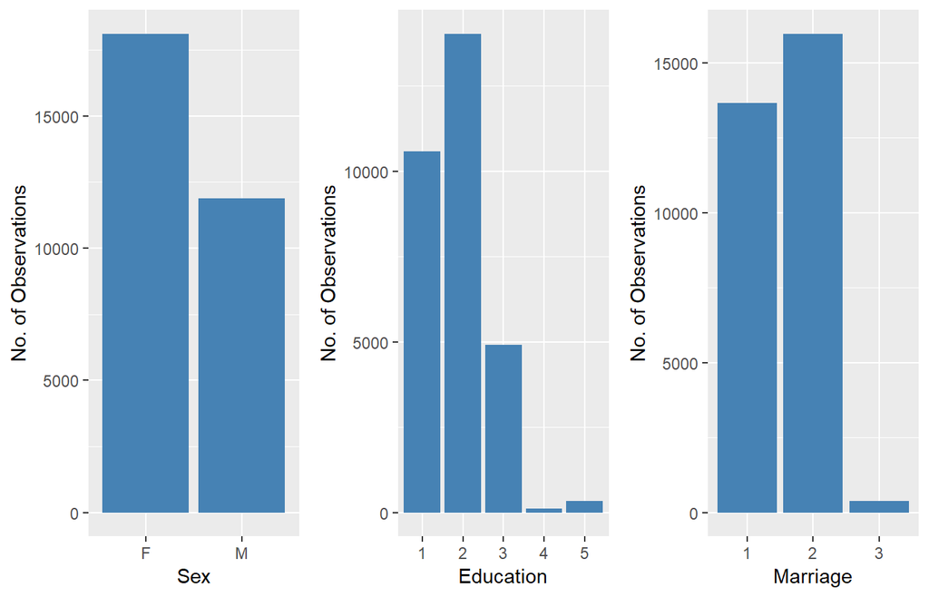

```r
p1 = ggplot(data,aes(data$SEX))+geom_bar(fill="steelblue")+scale_x_discrete("Sex")+scale_y_continuous("No. of Observations")
p2 = ggplot(data,aes(data$EDUCATION))+geom_bar(fill="steelblue")+scale_x_discrete("Education")+scale_y_continuous("No. of Observations")
p3 = ggplot(data,aes(data$MARRIAGE))+geom_bar(fill="steelblue")+scale_x_discrete("Marriage")+scale_y_continuous("No. of Observations")
grid.arrange(p1,p2,p3,nrow = 1)
```

From the above graphs we made the following observations: 1. The number of females are more in the dataset as compared to number of males. 2. Most of the customers achieved at least university education level. 3. A majority of the customers is single.

###### 2.3.5.1.1.2 Payment Status

According to the description, PAY_x is a set of categorical variables with the levels: -1 = pay duly 1 = payment delay for one month 2 = payment delay for two months, ..8 = payment delay for 8 months and 9=payment delay for 9 months and above.

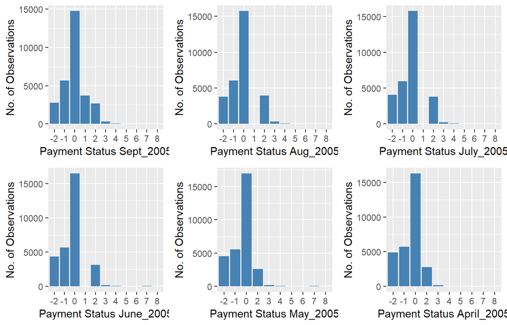

```r
p4 = ggplot(data,aes(data$PAY_STS_SEPT))+geom_bar(fill="steelblue")+scale_x_discrete("Payment Status Sept_2005")+scale_y_continuous("No. of Observations")
p5 = ggplot(data,aes(data$PAY_STS_AUG))+geom_bar(fill="steelblue")+scale_x_discrete("Payment Status Aug_2005")+scale_y_continuous("No. of Observations")
p6 = ggplot(data,aes(data$PAY_STS_JULY))+geom_bar(fill="steelblue")+scale_x_discrete("Payment Status July_2005")+scale_y_continuous("No. of Observations")
p7 = ggplot(data,aes(data$PAY_STS_JUNE))+geom_bar(fill="steelblue")+scale_x_discrete("Payment Status June_2005")+scale_y_continuous("No. of Observations")
p8 = ggplot(data,aes(data$PAY_STS_MAY))+geom_bar(fill="steelblue")+scale_x_discrete("Payment Status May_2005")+scale_y_continuous("No. of Observations")
p9 = ggplot(data,aes(data$PAY_STS_APRIL))+geom_bar(fill="steelblue")+scale_x_discrete("Payment Status April_2005")+scale_y_continuous("No. of Observations")
grid.arrange(p4,p5,p6,p7,p8,p9,nrow = 2)
```

From the above graphs we made the following observation(s): We observed undocumented values for the PAY attributes i.e “0” &“-2” We went back to Kaggle and searched for related discussions in the forum and we found that these values have the following meaning. * -2 = No consumption * 0 = The use of revolving credit card. Source: https://www.kaggle.com/uciml/default-of-credit-card-clients-dataset/discussion/34608

So from here we found out that there are high number of observations where people are using revolving credit card. We also observed that there is a spike in payment delays in September 2005.

##### 2.3.5.1.2 Numerical Features

We would like to explore the distributions of the numerical variables:

###### 2.3.5.1.2.1 Age

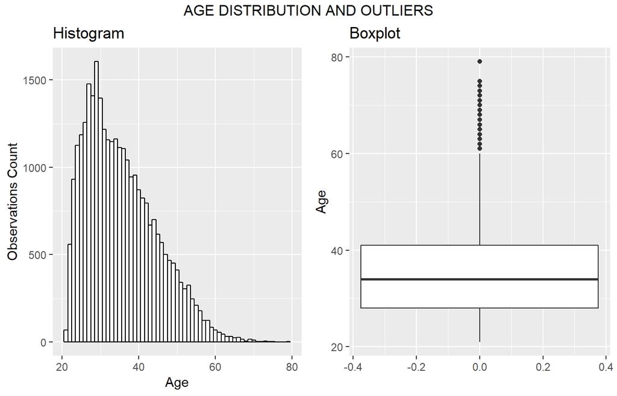

```r
p10 = ggplot(data, aes(data$AGE)) + geom_histogram(binwidth = 1,colour="black",fill="white")+  scale_x_continuous("Age")+scale_y_continuous("Observations Count")+labs(title = "Histogram")
p11 = ggplot(data, aes(,data$AGE)) + geom_boxplot(fill = "white")+  scale_y_continuous("Age")+scale_x_continuous("")+labs(title="Boxplot")
grid.arrange(p10,p11,nrow =1,top="AGE DISTRIBUTION AND OUTLIERS" )
```

As we can see above, the use of credit cards concentrates on younger age (< 40) with the average age of 35.4855.

###### 2.3.5.1.2.2 Limit of Balance

Lets explore the distribution and the outliers for the limit of balance.

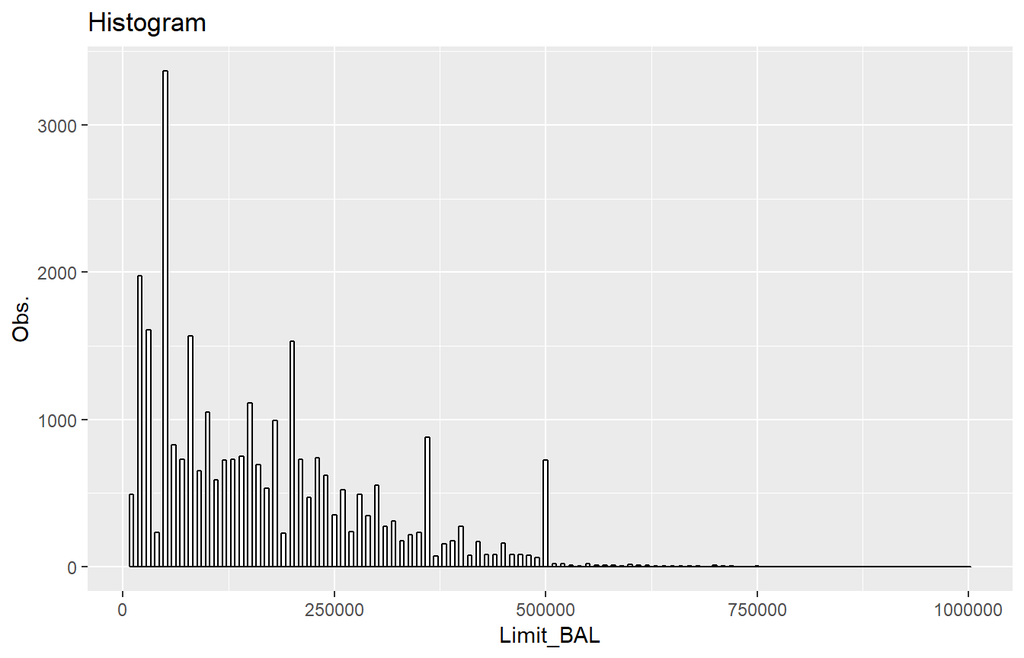

```r
ggplot(data, aes(data$LIMIT_BAL)) + geom_histogram(binwidth = 5000,colour="black",fill="white")+  scale_x_continuous("Limit_BAL")+scale_y_continuous("Obs.")+labs(title = "Histogram")
```

We can see that from the above histogram, the customers usually have the following limit balances: 20K, 30K, 50K, 80K, 200K and 500K. We also observed that a sizable number of customers were authorized high credit card limits above 250K.

Now lets us check for outliers with a boxplot.

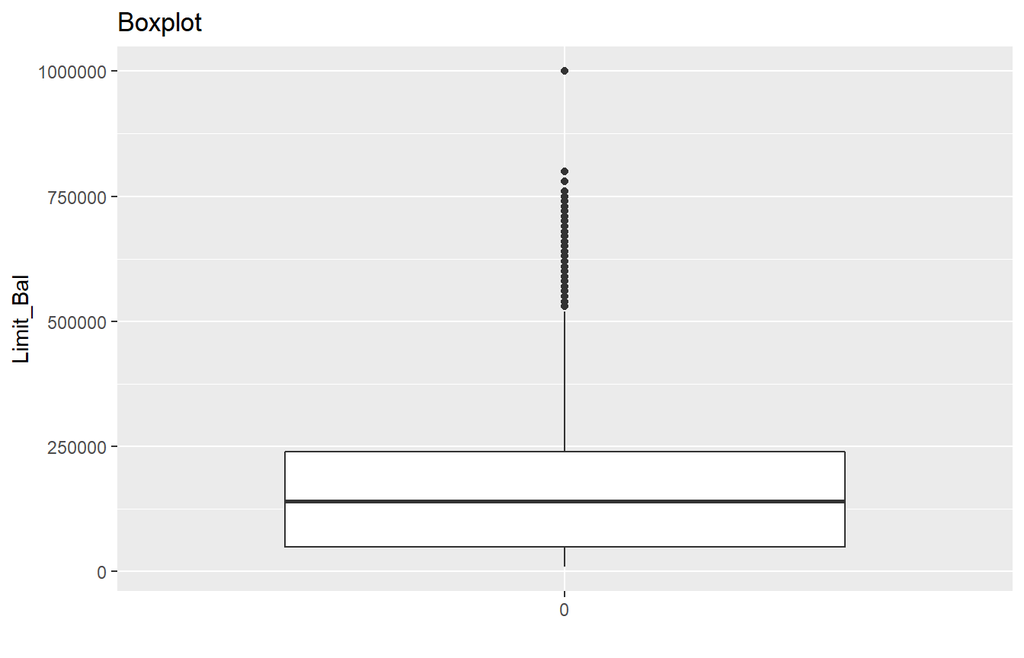

```r
ggplot(data, aes(x=factor(0),y=data$LIMIT_BAL)) + geom_boxplot(fill = "white")+
  scale_y_continuous("Limit_Bal")+scale_x_discrete("")+labs(title="Boxplot")
```

```r
LIMIT_BAL_OUT <- with(data, which(LIMIT_BAL > 600000))
NROW(LIMIT_BAL_OUT)
```

```
## [1] 79
```

There are 79 accounts whose limits exceed 600K. Our credit risk monitoring team has a special monitoring program to track these accounts because we could expose to larger losses when these customers fully draw down the limits and then default on their debts.

###### 2.3.5.1.2.3 Average Billing Amount & Payment Amount

As for the billing balances and payment amounts, since we have 6 months of data, analyzing the balances for each month might not add much value in the data exploring exercise. We decided to take the averages of the billing amounts and payment amounts across the 6-month period for each account and then observe the distributions. We will also add two columns to populate the mean values of bill and payment amounts respectively.

```r
data$billmean <- rowMeans(data[c('BILL_AMT_SEPT', 'BILL_AMT_AUG','BILL_AMT_JULY','BILL_AMT_JUNE','BILL_AMT_MAY','BILL_AMT_APRIL')], na.rm=TRUE)
data$paymean<-rowMeans(data[c('PAY_AMT_SEPT','PAY_AMT_AUG','PAY_AMT_JULY','PAY_AMT_JUNE','PAY_AMT_MAY','PAY_AMT_APRIL')], na.rm=TRUE)
```

Now that we have introduced the mean attributes let us plot for the same.

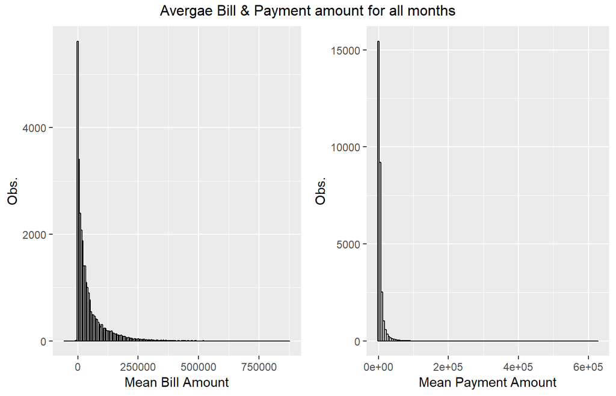

```r
p12 = ggplot(data, aes(data$billmean)) + geom_histogram(binwidth = 5000,colour="black",fill="white")+  scale_x_continuous("Mean Bill Amount")+scale_y_continuous("Obs.")
p24 = ggplot(data, aes(data$paymean)) + geom_histogram(binwidth = 5000,colour="black",fill="white")+  scale_x_continuous("Mean Payment Amount")+scale_y_continuous("Obs.")
grid.arrange(p12,p24,nrow=1,top = "Avergae Bill & Payment amount for all months")
```

Based on the above charts, we observe that the customers tend to pay off the credit cards bills in smaller amounts than the actual amounts in the bill statements as the distribution of the payment amounts are very skewed towards smaller values. The disbution of the bill amounts is also skewed but it has fatter tail at the high bill amount area.

The skewness of these distributions can be further visualized in the boxplots below:

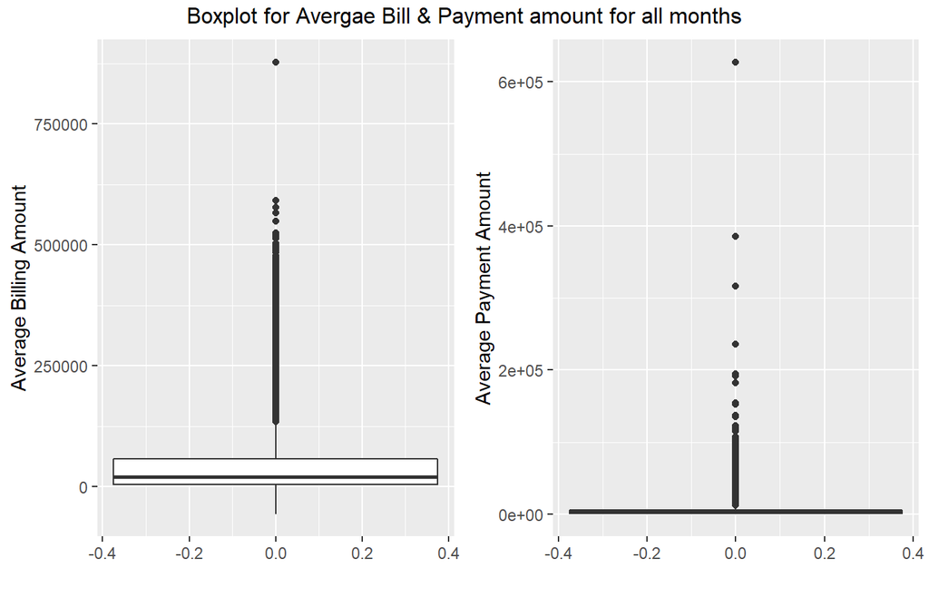

```r
p18 = ggplot(data, aes(,data$billmean)) + geom_boxplot(fill = "white")+ scale_y_continuous("Average Billing Amount")+scale_x_continuous("")
p30 = ggplot(data, aes(,data$paymean)) + geom_boxplot(fill = "white")+  scale_y_continuous("Average Payment Amount")+scale_x_continuous("")
grid.arrange(p18,p30,ncol=2,top="Boxplot for Avergae Bill & Payment amount for all months")
```

Once again, the boxplots verify our observations above.

#### 2.3.5.2 Bivariate Exploration

We will look at the following relationships in the dataset:

- Marriage Status and Repayment Status
- Sex and Repayment Status
- Education and Repayment Status

##### 2.3.5.2.1 Marriage status and Repayment Status

We are using the repayment data as of Seotember 2005 for us to draw the insights.

Let us take a look at the relationship between marriage status and re-payment status as of September 2005:

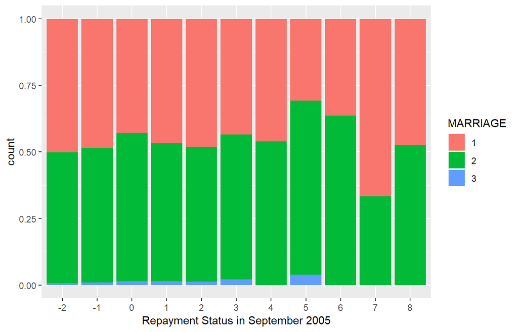

```r
ggplot(data,aes(x=PAY_STS_SEPT,fill = MARRIAGE))+geom_bar(position = "fill")+scale_x_discrete("Repayment Status in September 2005")
```

To recap, here is the description of the repayment status flag: (-1=pay duly, 1=payment delay for one month, 2=payment delay for two months, … 8=payment delay for eight months, 9=payment delay for nine months and above)

Based on the chart above, we observe that majority of the customers who are behind on their credit card payments are mostly single, except the 7-month delay bucket.

##### 2.3.5.2.2 Sex and Repayment Status

Now lets check if there is any trend we can observe if we plot the repayment status w.r.t gender.

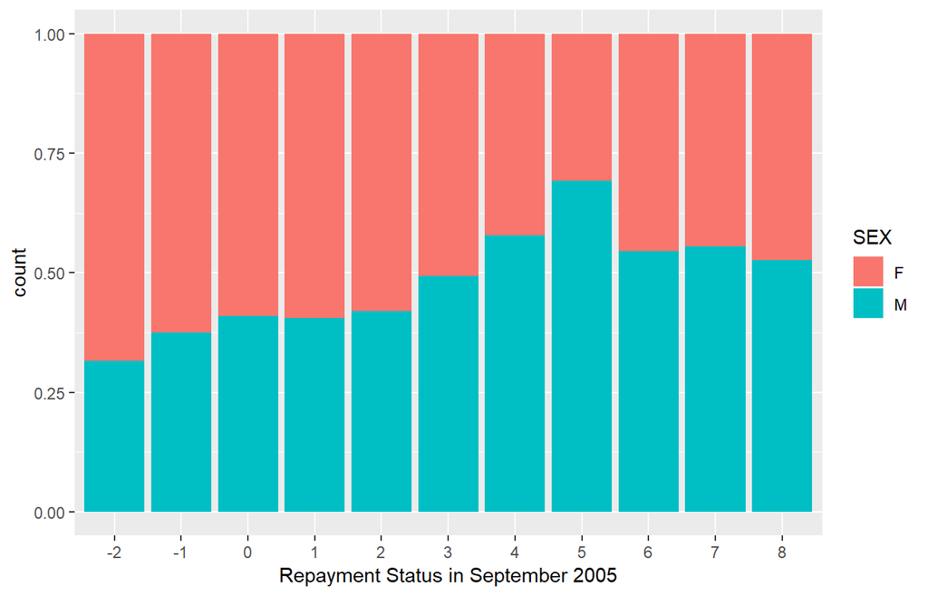

```r
ggplot(data,aes(x=PAY_STS_SEPT,fill = SEX))+geom_bar(position = "fill")+scale_x_discrete("Repayment Status in September 2005")
```

Let us check for the rest of the months to see if it is the same situation every month.

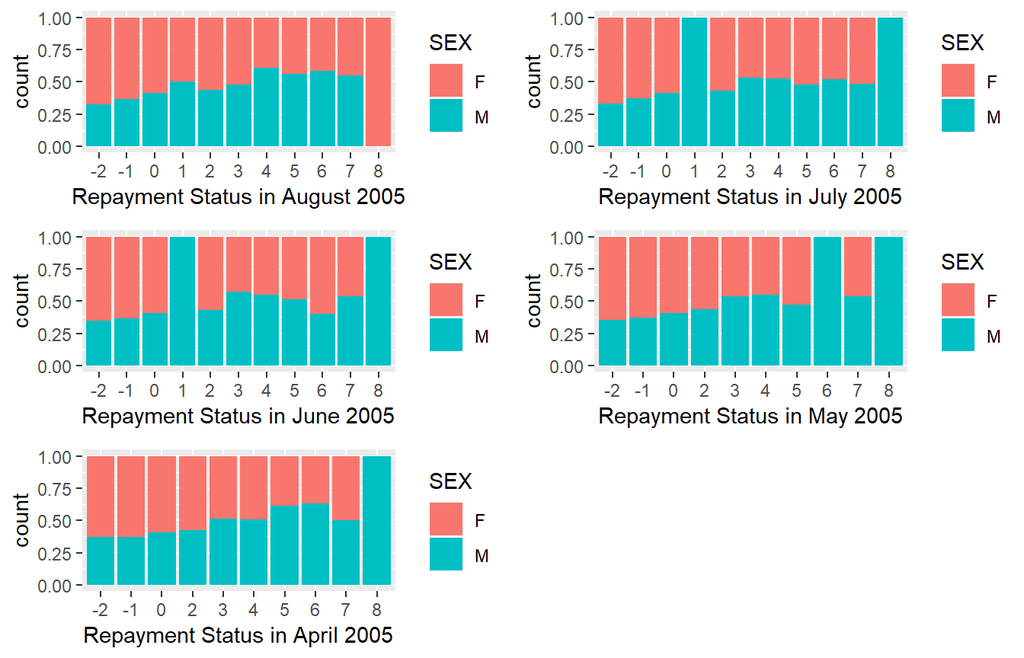

```r
b1 = ggplot(data,aes(x=PAY_STS_AUG,fill = SEX))+geom_bar(position = "fill")+scale_x_discrete("Repayment Status in August 2005")
b2 = ggplot(data,aes(x=PAY_STS_JULY,fill = SEX))+geom_bar(position = "fill")+scale_x_discrete("Repayment Status in July 2005")
b3 = ggplot(data,aes(x=PAY_STS_JUNE,fill = SEX))+geom_bar(position = "fill")+scale_x_discrete("Repayment Status in June 2005")
b4 = ggplot(data,aes(x=PAY_STS_MAY,fill = SEX))+geom_bar(position = "fill")+scale_x_discrete("Repayment Status in May 2005")
b5 = ggplot(data,aes(x=PAY_STS_APRIL,fill = SEX))+geom_bar(position = "fill")+scale_x_discrete("Repayment Status in April 2005")
grid.arrange(b1,b2,b3,b4,b5,nrow = 3)
```

Just as we suspected! The males are more likely to be behind their credit card bills.

##### 2.3.5.2.3 Education and Repayment Status

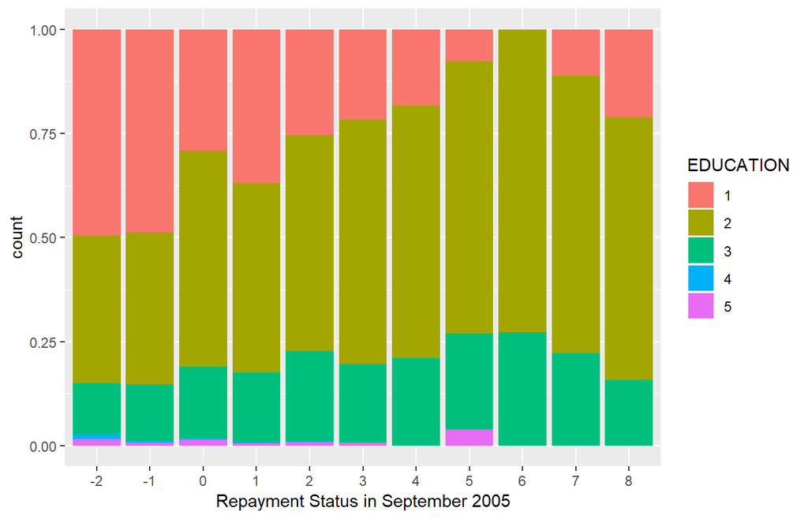

```r
ggplot(data,aes(x=PAY_STS_SEPT,fill = EDUCATION))+geom_bar(position = "fill")+scale_x_discrete("Repayment Status in September 2005")
```

To recap, here is the description of the repayment status flag: (-1=pay duly, 1=payment delay for one month, 2=payment delay for two months, … 8=payment delay for eight months, 9=payment delay for nine months and above). The education level flag has the following legend: (1=graduate school, 2=university, 3=high school, 4=others, 5=unknown)

We observe that most customers who are behind their credit card payments have at least univerity education. Since the observation is most likely the same for the other months, we won’t repeat the analysus here.

# 3 Data Preparation

## 3.1 Check for Missing Values

Now that we have explored the original data lets look for missing values.

```r
sum(is.na.data.frame(data))
```

```
## [1] 0
```

So we can see from above that we have 0 missing values so we don’t have to fill in missing values.

## 3.2 Data Cleaning

Earlier we had introduced two new attributes (billmean & paymean) for our data explorations. We will now remove them as we don’t need them in our modelling work.

```r
data$billmean<-NULL
data$paymean<-NULL
```

## 3.3 Create Payment Ratios Columns

Let’s look at the relationship between the Bill_AMT[N] and Pay_AMT[N] variables, where N is from September to April 2005. Normally, a bill statement is issued in the month after the payment month. That is, for example, a customer receives the statement in July 2005 in which the customer is required to clear the balance in August 2005.

```r
data[1,colnames(data) %in% c("BILL_AMT_JULY","PAY_AMT_AUG")]
```

```
##   BILL_AMT_JULY PAY_AMT_AUG
## 1           689         689
```

We created ratios to see how much of the previous month bill did the user pay off. We made some assumptions where if the Bill Amount is negative then the ratio should be 1 has the bill has been overpaid.

```r
data$Ratio_BILL_AUG <- ifelse(data$PAY_AMT_SEPT==0,0,ifelse(data$BILL_AMT_AUG <=0,1,data$PAY_AMT_SEPT/data$BILL_AMT_AUG))
data$Ratio_BILL_JULY <- ifelse(data$PAY_AMT_AUG==0,0,ifelse(data$BILL_AMT_JULY <=0,1,data$PAY_AMT_AUG/data$BILL_AMT_JULY))
data$Ratio_BILL_JUNE <- ifelse(data$PAY_AMT_JULY==0,0,ifelse(data$BILL_AMT_JUNE <=0,1,data$PAY_AMT_JULY/data$BILL_AMT_JUNE))
data$Ratio_BILL_MAY <- ifelse(data$PAY_AMT_JUNE==0,0,ifelse(data$BILL_AMT_MAY <=0,1,data$PAY_AMT_JUNE/data$BILL_AMT_MAY))
data$Ratio_BILL_APRIL <- ifelse(data$PAY_AMT_MAY==0,0,ifelse(data$BILL_AMT_APRIL <=0,1,data$PAY_AMT_MAY/data$BILL_AMT_APRIL))
```

# 4 Modelling

## 4.1 Select Modelling Technique

We chose to start with a K-means clustering alorgirthm as most of our data are numeric. The first step for running the alogirthm is to make all the categorical variables into numeric by encoding them. We chose to implement one hot encoding because our variables are nominal and not ordinal.

## 4.2 Data Encoding

```r
data_f <- data

#encod categorical columns
dummies_model <- dummyVars(ï..ID ~ ., data=data_f)

# Create the dummy variables using predict. The Y variable (ï..ID) will not be present in encod
encod <- predict(dummies_model, newdata = data_f)

# # Convert to dataframe
data_encoded <- data.frame(encod)
```

Now that the data is encoded and all variables are numeric, we can implement the K-means algorithm. The K-means algorithm works by creating K cluster. Each cluster is based on feature similarity. The alogirthm starts by randomly picking K centroids, then the alogirthm iterates through each point and assigns it to the nearest cluster based a distance formula. (ex: Euclidean). After each point has been assigned a cluster, the centroids are re-calculated by taking the mean distances of all data points in the clusters, next the points are reclassifed again until a stopping criteria is met. (No points change clusters or the mean of all data points in the cluster is minimized.)

## 4.3 Data Normalization

Since the K-means algorithm using distance to find the nearest point we need to ensure all the variables are on the same range. We do this by normalizing the data.

```r
df <- data_encoded

normalize = function(x) {
  return ((x - min(x)) / (max(x) - min(x)))
}

df = as.data.frame(lapply(df, normalize))
```

## 4.4 Finding Optimal Number of Clusters (K)

Before we run the K Mean algorithm we need to find the optimal K clusters. To find the optimal number of clusters we used the Elbow method. The elbow method finds the optimal K value by running mulptiple K-Means for K from 1 to N and calculateing the Sum of Squared errors (SSE). We then plot each SSE for each K, we then chose an optimal value of K such that it has a low SSE but further increase of K would make little improvement to the SSE. That K value would be the elbow point of the plot.

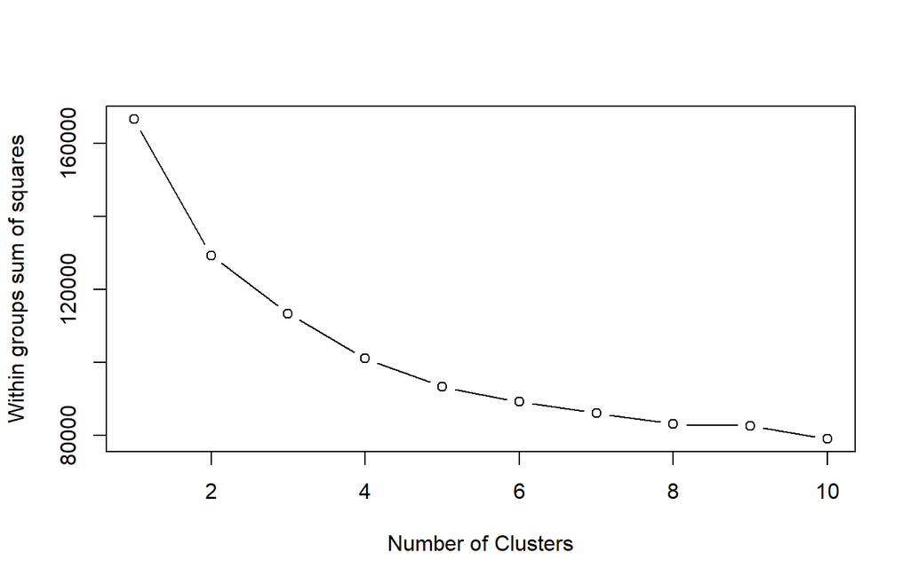

```r
#Find Optimal K using Elbow method

wssplot <- function(data, nc=15, seed=1234){
  wss <- (nrow(data)-1)*sum(apply(data,2,var))
  for (i in 2:nc){
    set.seed(seed)
    wss[i] <- sum(kmeans(data, centers=i, nstart=5)$withinss)}
  plot(1:nc, wss, type="b", xlab="Number of Clusters",
       ylab="Within groups sum of squares")}

wssplot(df, nc=10)
```

Based on the Elbow method, we found the optimal number to be 4. Beyond 4, we see gradually decreasing improvements on the SSE.

## 4.5 Building K-Means Model

```r
set.seed(9897665)

kmeans.result <- kmeans(df, centers=4, nstart=15, iter.max = 100)
```

## 4.6 K-Means Model Results

### 4.6.1 Cluster Assessments

By now, each account is assigned to a cluster number. The table below displays the number of accounts assigned to the corresponding clusters.

```r
#ClusterSize
table(kmeans.result$cluster)
```

```
##
##     1     2     3     4
##  3997 15529  6229  4245
```

We can see Cluster 2 is by far the largest cluster over 2 times the next biggest, cluster 1 and 4 are roughly the same size.

### 4.6.2 Numeric Variables

We will first look at each cluster in regards to our numeric variables.

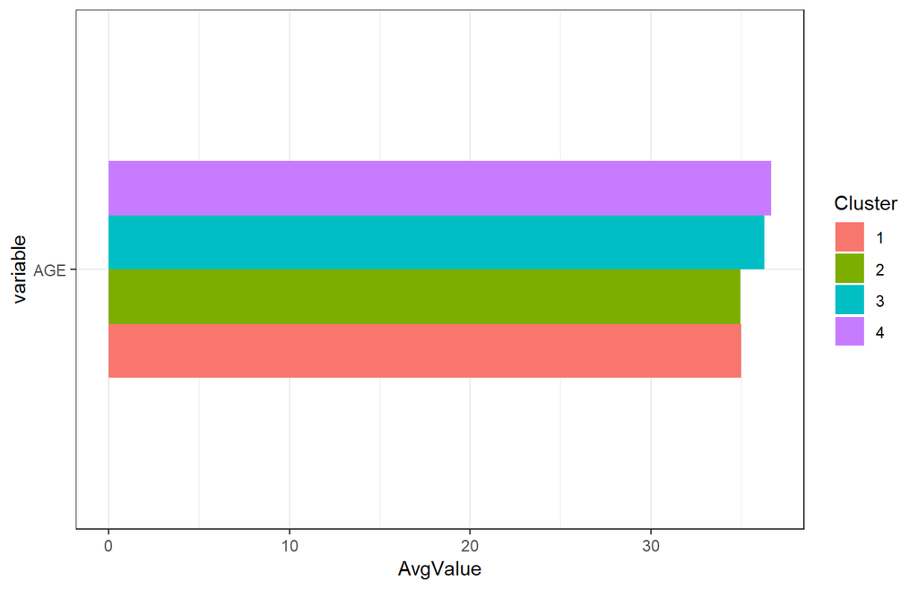

```r
#Create 2 data sets one with Categorical and one with Numeric variables
nn <- data[,!colnames(data) %in% c('?..ID','SEX','EDUCATION','MARRIAGE','PAY_STS_SEPT','PAY_STS_AUG','PAY_STS_JULY','PAY_STS_JUNE','PAY_STS_MAY','PAY_STS_APRIL','ï..ID')]
cc <- data[,colnames(data) %in% c('SEX','EDUCATION','MARRIAGE','PAY_STS_SEPT','PAY_STS_AUG','PAY_STS_JULY','PAY_STS_JUNE','PAY_STS_MAY','PAY_STS_APRIL','ï..ID','AGE')]

#Add in Cluster results
nn$Cluster <- kmeans.result$cluster
cc$Cluster <- kmeans.result$cluster

#Transpose data
mn <- melt(nn, id.vars = c("Cluster"))

mc <- melt(cc, id.vars = c("Cluster"))

#Aggregate Average value for each cluster and numeric variable
a_mn <- sqldf('SELECT Cluster, Variable, avg(value) as AvgValue
FROM mn
GROUP BY Cluster, Variable')


#Factor Cluster varaible to be discrete
a_mn$Cluster <- as.factor(a_mn$Cluster)

#Plot clusters and variables

#Age
Age_d <- ggplot(data = a_mn[a_mn$variable %in% c("AGE"),], aes(x = variable, y = AvgValue, group = Cluster, fill = Cluster))
Age_d <- Age_d + geom_bar(stat = "identity", width = 0.5, position = "dodge")
Age_d <- Age_d + theme_bw()
Age_d <- Age_d +  coord_flip()

Age_d
```

We can see that the average for all the clusters doesnt not vary too much. They are all aroudn 35 to 36 years old.

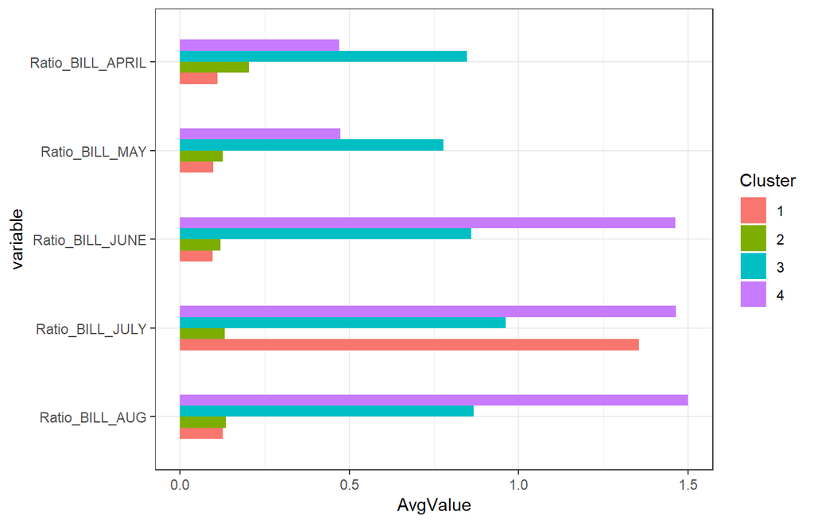

```r
#Ratios of Payment to Bill

Paid <- ggplot(data = a_mn[a_mn$variable %in% c("Ratio_BILL_AUG","Ratio_BILL_JULY","Ratio_BILL_JUNE","Ratio_BILL_MAY","Ratio_BILL_APRIL"),], aes(x = variable, y = AvgValue, group = Cluster, fill = Cluster))
Paid <- Paid + geom_bar(stat = "identity", width = 0.5, position = "dodge")
Paid <- Paid + theme_bw()
Paid <- Paid +  coord_flip()

Paid
```

We can see that cluster 3 and 4 tend to pay more of their bills then the other cluster. The only anonoly is in July for cluster 1, they had a spike in paying their bills.

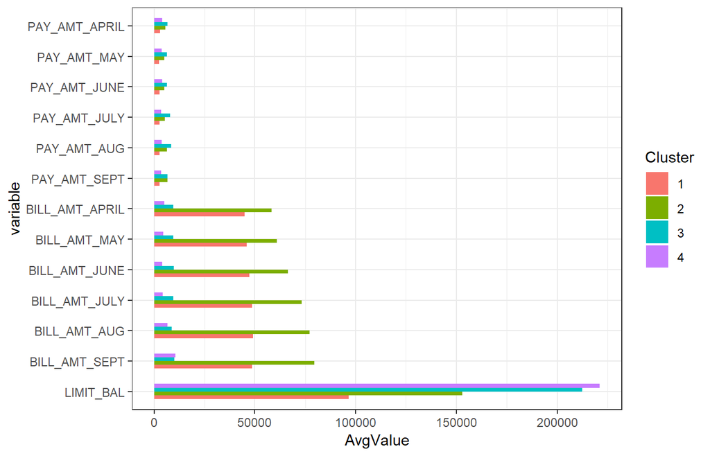

```r
x <- ggplot(data = a_mn[!a_mn$variable %in% c("Ratio_BILL_AUG","Ratio_BILL_JULY","Ratio_BILL_JUNE","Ratio_BILL_MAY","Ratio_BILL_APRIL","AGE"),], aes(x = variable, y = AvgValue, group = Cluster, fill = Cluster))
x <- x + geom_bar(stat = "identity", width = 0.5, position = "dodge")
x <- x + theme_bw()
x <- x +  coord_flip()

x
```

From the above we can see that Cluster 1 and 2 have a significant higher averager bill then the other clusters. Cluster 1 and 2 also have the lower limit balance. Cluster 2 and 3 have the highest average payment amount.

```r
#Crosstab Data

reshape2::dcast(a_mn, Cluster ~ variable, value.var = "AvgValue")
```

```
##   Cluster LIMIT_BAL      AGE BILL_AMT_SEPT BILL_AMT_AUG BILL_AMT_JULY
## 1       1  96634.98 35.00475      48690.82    49137.548     48700.466
## 2       2 152971.19 34.96143      79506.33    77033.567     73314.743
## 3       3 212542.94 36.30021      10133.33     8708.996      9413.277
## 4       4 221168.43 36.65984      10437.78     6705.976      4381.373
##   BILL_AMT_JUNE BILL_AMT_MAY BILL_AMT_APRIL PAY_AMT_SEPT PAY_AMT_AUG
## 1     47375.830    46041.498      44989.017     2781.502    2624.575
## 2     66372.005    60982.473      58362.544     6636.756    6358.185
## 3      9793.153     9430.603       9433.209     6498.684    8517.020
## 4      3965.809     4611.098       5008.318     3591.818    3617.364
##   PAY_AMT_JULY PAY_AMT_JUNE PAY_AMT_MAY PAY_AMT_APRIL Ratio_BILL_AUG
## 1     2633.851     2610.883    2396.976      2965.903      0.1261034
## 2     5284.946     5033.507    5067.170      5487.344      0.1347937
## 3     7961.069     6342.452    6335.285      6746.469      0.8667704
## 4     3435.458     3927.947    3828.114      4092.730      1.4992763
##   Ratio_BILL_JULY Ratio_BILL_JUNE Ratio_BILL_MAY Ratio_BILL_APRIL
## 1       1.3543676      0.09570897     0.09840733        0.1096265
## 2       0.1314307      0.11921691     0.12562899        0.2022969
## 3       0.9623167      0.85894415     0.77730787        0.8464359
## 4       1.4634386      1.46275640     0.47339964        0.4698020
```

For each cluster we calculated the average value for each numeric variable. From these average we are able to describe the clusters.

### 4.6.3 Categorical Variables and Age

Next we will look at each cluster with respect to the categorical variables and age.

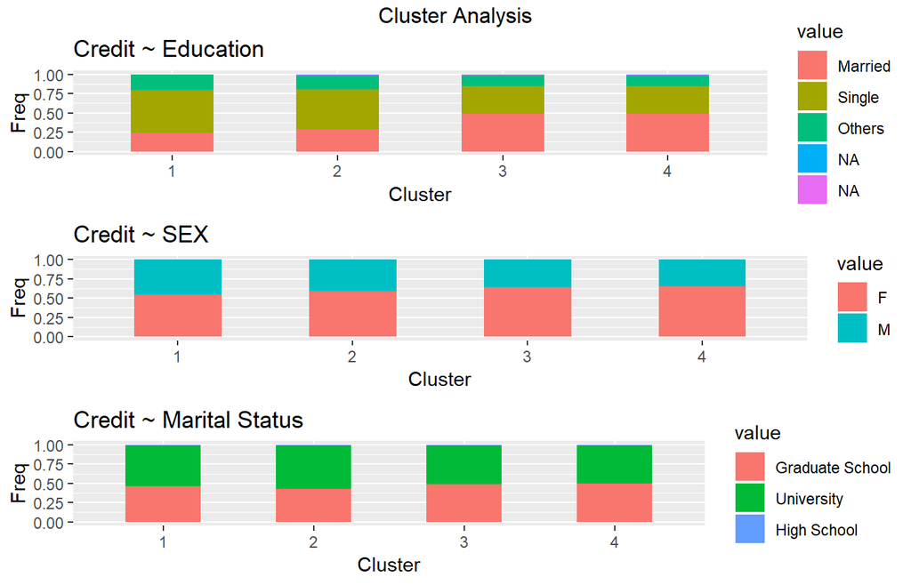

```r
#Aggregate Freqeuncy for each cluster and categorical variable
a_mc <- sqldf("SELECT Cluster, Variable,Value, COUNT(*) as Freq
FROM mc
GROUP BY Cluster, Variable,Value")

#Factor Cluster varaible to be discrete
a_mc$Cluster <- as.factor(a_mc$Cluster)

#Creat Plot clusters and variables
edu <- ggplot(data = a_mc[a_mc$variable =="EDUCATION",], aes(x = Cluster, y = Freq, group = variable, fill = value)) + geom_bar(stat = "identity", width = 0.5, position = "fill") + labs(title = "Credit ~ Education") + scale_fill_discrete(labels=c("Married","Single","Others"))

sex <- ggplot(data = a_mc[a_mc$variable =="SEX",], aes(x = Cluster, y = Freq, group = variable, fill = value)) + geom_bar(stat = "identity", width = 0.5, position = "fill") + labs(title = "Credit ~ SEX")

mar <- ggplot(data = a_mc[a_mc$variable =="MARRIAGE",], aes(x = Cluster, y = Freq, group = variable, fill = value)) + geom_bar(stat = "identity", width = 0.5, position = "fill") + labs(title = "Credit ~ Marital Status") + scale_fill_discrete(labels=c("Graduate School","University","High School","Others"))

pay <- ggplot(data = a_mc[a_mc$variable=='PAY_STS_SEPT'|a_mc$variable=='PAY_STS_AUG'|a_mc$variable=='PAY_STS_JULY'|a_mc$variable=='PAY_STS_JUNE'|a_mc$variable=='PAY_STS_MAY'|a_mc$variable=='PAY_STS_APRIL',], aes(x = Cluster, y = Freq, group = variable, fill = value))

pay <- pay + geom_bar(stat = "identity", width = 0.5, position = "fill") + facet_grid(. ~ variable)  + labs(title = "Credit Balance Paided: Cluster Analysis")
pay <- pay +  coord_flip()+ theme(axis.title.x=element_blank(),axis.text.x=element_blank(),axis.ticks.x=element_blank())

grid.arrange(edu,sex,mar,nrow = 3,top = "Cluster Analysis")
```

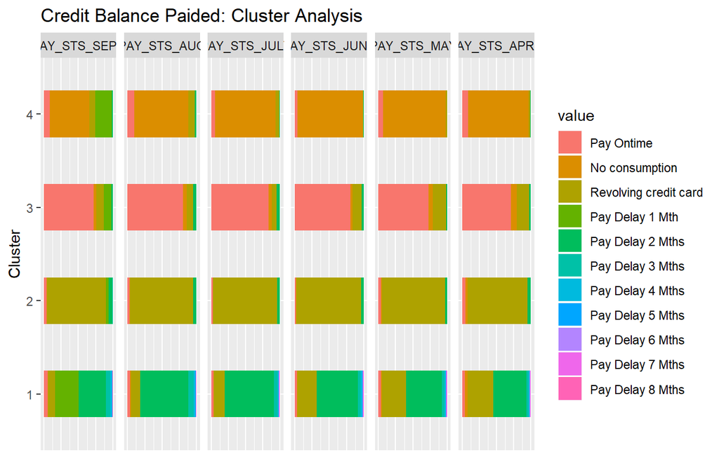

```r
pay + scale_fill_discrete(labels=c("Pay Ontime","No consumption","Revolving credit card","Pay Delay 1 Mth","Pay Delay 2 Mths","Pay Delay 3 Mths","Pay Delay 4 Mths","Pay Delay 5 Mths","Pay Delay 6 Mths","Pay Delay 7 Mths","Pay Delay 8 Mths"))
```

For each cluster we calculated the frequency value for each categorical variable. From these frequencies we are able to describe the clusters.

### 4.6.4 Visualize Model with PCA

We will use Principle Componet Analysis (PCA) to help us Visualize our clusters. PCA works by reducing dimensoinality of the data. We want to reduce the dimensionality to 2d because it will allow us to graph the clusters. PCAcreates new columns that are linearly uncorrelated variables, and sorts thems in descending where PC1 will account for the highest variability of the data, and PC2 will be seocnd most and so on.

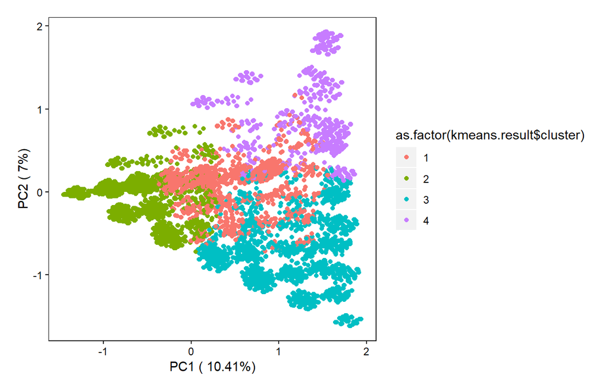

```r
df_pca <- prcomp(df)
df_out <- as.data.frame(df_pca$x)

p<-ggplot(df_out,aes(x=PC1,y=PC2,color = as.factor(kmeans.result$cluster ) ))
theme<-theme(panel.background = element_blank(),panel.border=element_rect(fill=NA),panel.grid.major = element_blank(),panel.grid.minor = element_blank(),strip.background=element_blank(),axis.text.x=element_text(colour="black"),axis.text.y=element_text(colour="black"),axis.ticks=element_line(colour="black"),plot.margin=unit(c(1,1,1,1),"line"))
percentage <- round(df_pca$sdev / sum(df_pca$sdev) * 100, 2)
percentage <- paste( colnames(df_out), "(", paste( as.character(percentage), "%", ")", sep="") )

p<-p+geom_point()+theme+xlab(percentage[1]) + ylab(percentage[2])

p
```

Looking at the vizualized data we can see some of the clusters are well formed and there is minimal overlap, clusters 2,3 and 4 are almost fully homogeneous from each other. Cluster 1 seems to be overlapping with parts of all the other clusters.

### 4.6.5 Finding Anomalies (Outliers)

#### 4.6.5.1 Anomaly Detection using K-Means

To find anomalies we first used the K means clusters centroids to calculate the distnace each point is away from there cluster centroid. We then take the top 5 farthest points from each cluster centroid and plot them.

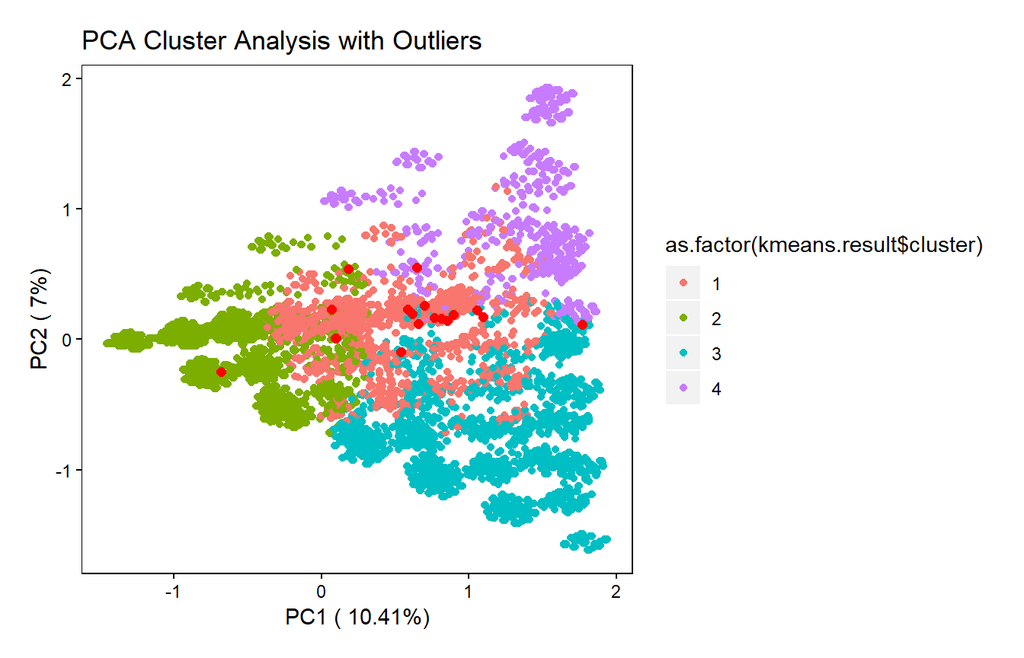

```r
#Find the Center of each cluster
centers <- kmeans.result$centers[kmeans.result$cluster, ]

# Calculate distance each point is from the center of the cluster
distances <- sqrt(rowSums((df - centers)^2))
# Take the top 20 fartherest points from the cluster center
outliers <- order(distances, decreasing=T)[1:20]

dst <- as.data.frame(distances)

dst$cluster <- kmeans.result$cluster
dst$ID <- seq.int(nrow(data))

outliers <- dst %>%
  group_by(cluster) %>%
  top_n(n = 5, wt = distances)

#Plot Outliers
p<-p + geom_point(data=df_out[outliers$ID,],aes(x=PC1,y=PC2), colour="red", size=2)+ggtitle("PCA Cluster Analysis with Outliers")

p
```

#### 4.6.5.2 Anomaly Detection using Local Outlier Factor (LOF)

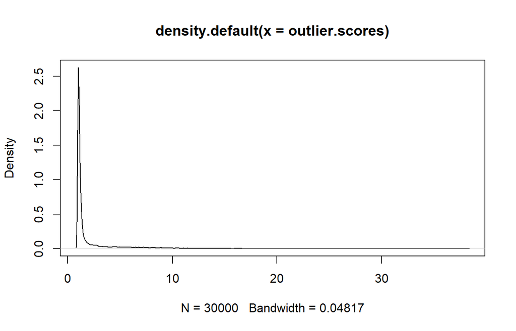

```r
#run LOF Model takes awhile 50 minutes
outlier.scores <- lofactor(df,k=50)
#Plotdensity of Outliers
plot(density(outlier.scores))
```

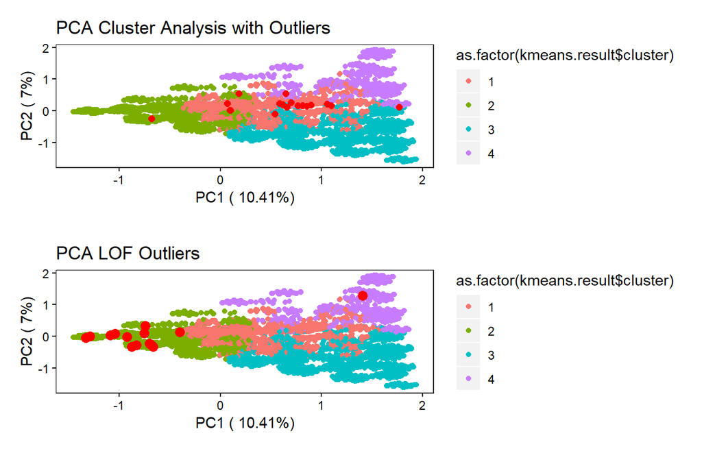

```r
#Plot outliers from LOF -->
outliers_lof <- order(outlier.scores, decreasing=T)[1:20]


p_lof<-ggplot(df_out,aes(x=PC1,y=PC2,color = as.factor(kmeans.result$cluster ) ))+geom_point()+theme+xlab(percentage[1]) + ylab(percentage[2]) + geom_point(data=df_out[outliers_lof,],aes(x=PC1,y=PC2), colour="red", size=3)+ggtitle("PCA LOF Outliers")


#compare K-means outlier to LOF -->
grid.arrange(p, p_lof, nrow = 2,ncol = 1)
```

We can see how different the outliers found by the LOF model is from the k-means clusters model.

# 5 Evaluation

### 5.0.1 Assessment With Respect To Business Objectives

#### 5.0.1.1 K-Means Model

Our business objective for this project is to load in the dataset and identify clients that are in the anomaly group which may indicate high risk of defaulting on their credit card debts. The clustering algorithm allows us to identify the top 20 clients that belong to the anomaly group:

```r
customer_anomaly<-data[outliers$ID,!colnames(data) %in% c('ï..ID','Ratio_BILL_AUG','Ratio_BILL_JULY','Ratio_BILL_JUNE','Ratio_BILL_MAY','Ratio_BILL_APRIL')]
customer_anomaly$Cluster<-outliers$cluster
kable(customer_anomaly,caption="List of Customers Exhibiting Anomaly Characteristics using the K-Means Model")
```

List of Customers Exhibiting Anomaly Characteristics using the K-Means Model

|  | LIMIT_BAL | SEX | EDUCATION | MARRIAGE | AGE | PAY_STS_SEPT | PAY_STS_AUG | PAY_STS_JULY | PAY_STS_JUNE | PAY_STS_MAY | PAY_STS_APRIL | BILL_AMT_SEPT | BILL_AMT_AUG | BILL_AMT_JULY | BILL_AMT_JUNE | BILL_AMT_MAY | BILL_AMT_APRIL | PAY_AMT_SEPT | PAY_AMT_AUG | PAY_AMT_JULY | PAY_AMT_JUNE | PAY_AMT_MAY | PAY_AMT_APRIL | Cluster |
| --- | --- | --- | --- | --- | --- | --- | --- | --- | --- | --- | --- | --- | --- | --- | --- | --- | --- | --- | --- | --- | --- | --- | --- | --- |
| 1133 | 270000 | M | 1 | 1 | 44 | 3 | 3 | 4 | 4 | 4 | 4 | 256402 | 264267 | 271951 | 278509 | 283545 | 278436 | 17944 | 18112 | 15405 | 10000 | 0 | 0 | 1 |
| 2198 | 1000000 | F | 1 | 1 | 47 | 0 | 0 | 0 | -1 | 0 | 0 | 964511 | 983931 | 535020 | 891586 | 927171 | 961664 | 50784 | 50723 | 896040 | 50000 | 50000 | 50256 | 2 |
| 5006 | 90000 | F | 3 | 3 | 24 | -2 | -2 | -2 | -1 | 0 | 0 | 3700 | 20833 | 23968 | 13574 | 6800 | 1830 | 20108 | 4000 | 13574 | 14 | 5 | 13162 | 4 |
| 5297 | 500000 | F | 1 | 1 | 33 | -2 | -2 | -1 | -1 | -2 | -1 | 125 | -18088 | 1664089 | 121757 | 97115 | 377217 | 4366 | 1684259 | 121831 | 97670 | 379267 | 26759 | 3 |
| 5435 | 90000 | M | 3 | 1 | 45 | 2 | 0 | 0 | -1 | -1 | -2 | 37681 | 27664 | 18037 | 1696 | -4 | 2889 | 1519 | 5035 | 6700 | 0 | 2893 | 304 | 3 |
| 7640 | 20000 | M | 3 | 3 | 48 | 1 | -2 | -1 | 0 | 0 | 0 | -739 | -5978 | 16089 | 14457 | 20106 | 10258 | 0 | 42400 | 289 | 201 | 410 | 0 | 2 |
| 7956 | 50000 | F | 3 | 3 | 27 | 2 | 0 | -1 | -1 | -2 | -2 | 49929 | 49667 | 780 | 0 | 0 | 0 | 1750 | 780 | 0 | 0 | 0 | 0 | 3 |
| 8675 | 190000 | M | 3 | 1 | 54 | 1 | -2 | -2 | -1 | 0 | -1 | -596 | -1072 | -1548 | 40733 | 10876 | 2907 | 0 | 0 | 43500 | 2000 | 2907 | 3000 | 3 |
| 11555 | 150000 | M | 1 | 1 | 42 | 8 | 7 | 6 | 5 | 4 | 3 | 161569 | 159190 | 155821 | 153075 | 151269 | 149723 | 0 | 0 | 0 | 0 | 0 | 15 | 1 |
| 13636 | 20000 | M | 3 | 1 | 36 | 8 | 7 | 6 | 5 | 4 | 3 | 24166 | 23845 | 23214 | 22583 | 21662 | 21031 | 0 | 0 | 0 | 0 | 0 | 0 | 1 |
| 13826 | 120000 | F | 3 | 3 | 41 | 0 | 0 | -2 | -2 | -1 | -1 | 3307 | 0 | 0 | 0 | 1344 | 881 | 258 | 0 | 0 | 1344 | 929 | 599 | 4 |
| 16302 | 20000 | F | 3 | 3 | 32 | 0 | 0 | 0 | -2 | -2 | -1 | 19446 | 20650 | 0 | 0 | 0 | 1000 | 2000 | 0 | 0 | 0 | 1000 | 0 | 2 |
| 23040 | 220000 | F | 1 | 1 | 41 | 8 | 7 | 6 | 5 | 4 | 3 | 246915 | 243234 | 238172 | 232446 | 227800 | 225044 | 0 | 0 | 0 | 0 | 0 | 0 | 1 |
| 23938 | 150000 | M | 4 | 3 | 27 | -1 | -1 | 0 | 0 | -2 | -2 | 3462 | 1147 | 7002 | 0 | 0 | 0 | 1147 | 6000 | 0 | 0 | 0 | 0 | 3 |
| 24005 | 50000 | M | 3 | 2 | 27 | 0 | 0 | -2 | -2 | -1 | -1 | 32590 | -100 | 0 | 0 | 70 | 120 | 0 | 100 | 0 | 70 | 200 | 100 | 4 |
| 25870 | 510000 | F | 1 | 2 | 40 | 8 | 7 | 6 | 5 | 4 | 3 | 477094 | 469882 | 461402 | 452405 | 443657 | 437305 | 0 | 0 | 0 | 0 | 0 | 14000 | 1 |
| 25975 | 70000 | F | 2 | 1 | 33 | 0 | 0 | 5 | 4 | 3 | 3 | 56778 | 75037 | 73326 | 71568 | 72540 | 71148 | 20000 | 0 | 0 | 2700 | 0 | 0 | 2 |
| 27204 | 280000 | M | 3 | 3 | 42 | 1 | -2 | -1 | 0 | 0 | 0 | -191 | -191 | 5612 | 6917 | 10247 | 11822 | 0 | 6100 | 4000 | 3500 | 2500 | 2000 | 2 |
| 28191 | 80000 | F | 3 | 3 | 43 | 0 | 0 | -2 | -2 | -1 | -1 | 3408 | -11 | -11 | -11 | 2429 | 905 | 0 | 0 | 0 | 2440 | 905 | 9213 | 4 |
| 29195 | 130000 | M | 2 | 3 | 22 | 0 | 0 | -2 | -2 | -1 | -1 | 25200 | 0 | 0 | 0 | 500 | 0 | 0 | 0 | 0 | 500 | 0 | 0 | 4 |

#### 5.0.1.2 LOF Model

We have also run the LOF model and below are the Top 20 anomalies found by the LOF model.

```r
customer_anomaly_lof<-data[outliers_lof,!colnames(data) %in% c('ï..ID','Ratio_BILL_AUG','Ratio_BILL_JULY','Ratio_BILL_JUNE','Ratio_BILL_MAY','Ratio_BILL_APRIL')]
customer_anomaly_lof$Cluster<-outliers$cluster
kable(customer_anomaly_lof,caption="List of Customers Exhibiting Anomaly Characteristics using the LOF Model")
```

List of Customers Exhibiting Anomaly Characteristics using the LOF Model

|  | LIMIT_BAL | SEX | EDUCATION | MARRIAGE | AGE | PAY_STS_SEPT | PAY_STS_AUG | PAY_STS_JULY | PAY_STS_JUNE | PAY_STS_MAY | PAY_STS_APRIL | BILL_AMT_SEPT | BILL_AMT_AUG | BILL_AMT_JULY | BILL_AMT_JUNE | BILL_AMT_MAY | BILL_AMT_APRIL | PAY_AMT_SEPT | PAY_AMT_AUG | PAY_AMT_JULY | PAY_AMT_JUNE | PAY_AMT_MAY | PAY_AMT_APRIL | Cluster |
| --- | --- | --- | --- | --- | --- | --- | --- | --- | --- | --- | --- | --- | --- | --- | --- | --- | --- | --- | --- | --- | --- | --- | --- | --- |
| 20429 | 20000 | M | 2 | 2 | 24 | 0 | 0 | 0 | 0 | 4 | 3 | 5212 | 6462 | 7846 | 10715 | 10406 | 9953 | 1500 | 1500 | 3000 | 0 | 0 | 0 | 1 |
| 3801 | 10000 | F | 2 | 2 | 22 | 0 | -1 | 0 | 0 | 0 | 0 | 14896 | 12011 | 7929 | 7693 | 6838 | 3486 | 7000 | 4000 | 207 | 229 | 70 | 0 | 2 |
| 3023 | 20000 | F | 2 | 2 | 25 | 0 | 0 | 0 | 0 | 0 | 3 | 8011 | 9041 | 10903 | 11622 | 13280 | 12778 | 1320 | 2181 | 900 | 2000 | 0 | 0 | 4 |
| 2643 | 50000 | M | 2 | 2 | 25 | 0 | 0 | 0 | 0 | 0 | 3 | 21316 | 23038 | 24720 | 26370 | 29332 | 28574 | 2375 | 2375 | 2375 | 3547 | 0 | 0 | 3 |
| 18539 | 20000 | F | 2 | 2 | 23 | 0 | 0 | -1 | 0 | 0 | 0 | 10513 | 3367 | 444 | 20444 | 18976 | 19802 | 1000 | 444 | 20000 | 600 | 1000 | 1000 | 3 |
| 10570 | 50000 | M | 2 | 2 | 25 | 0 | 0 | 0 | 0 | 3 | 3 | 46741 | 48883 | 50074 | 60158 | 75277 | 90464 | 2900 | 2000 | 14455 | 16560 | 17000 | 0 | 2 |
| 11130 | 20000 | M | 2 | 2 | 22 | 0 | -1 | 0 | 0 | 0 | 0 | 19666 | 20076 | 19875 | 19659 | 19310 | 16286 | 20700 | 2000 | 800 | 465 | 1000 | 0 | 3 |
| 20674 | 20000 | M | 2 | 2 | 35 | 0 | 0 | 0 | 3 | 7 | 6 | 6855 | 11392 | 15863 | 20581 | 20298 | 19424 | 5000 | 5000 | 5000 | 0 | 0 | 1000 | 3 |
| 9308 | 30000 | F | 2 | 2 | 28 | 0 | 0 | 0 | 0 | 0 | 3 | 15280 | 16230 | 17153 | 17351 | 19509 | 18900 | 1500 | 1500 | 780 | 2600 | 0 | 900 | 1 |
| 11373 | 20000 | F | 4 | 2 | 22 | 0 | 0 | 0 | 0 | 0 | 0 | 17576 | 17632 | 18385 | 18657 | 8539 | 0 | 1500 | 1200 | 1000 | 1000 | 0 | 0 | 1 |
| 14780 | 30000 | F | 1 | 2 | 25 | 0 | 0 | 0 | 0 | 0 | -2 | 25115 | 26287 | 26602 | 21000 | 0 | 0 | 1886 | 1620 | 0 | 0 | 0 | 0 | 4 |
| 10311 | 50000 | F | 1 | 2 | 25 | 0 | 0 | -1 | 0 | 0 | 0 | 8107 | 4895 | 12128 | 12128 | 6000 | 0 | 1000 | 12128 | 0 | 0 | 0 | 0 | 2 |
| 10649 | 10000 | M | 1 | 2 | 22 | 0 | 0 | 0 | 0 | 0 | 3 | 4060 | 2774 | 3764 | 4001 | 5134 | 4762 | 1300 | 1200 | 300 | 1200 | 0 | 0 | 1 |
| 2551 | 30000 | F | 2 | 2 | 26 | 0 | 0 | -1 | 0 | 0 | 0 | 17341 | -1030 | 29718 | 27417 | 28489 | 28427 | 485 | 31509 | 1500 | 1502 | 1500 | 3000 | 3 |
| 21511 | 30000 | F | 1 | 2 | 23 | 0 | 0 | 0 | -1 | 0 | 0 | 10210 | 13754 | -191 | 24149 | 25452 | 25104 | 6000 | 250 | 25000 | 2000 | 1000 | 1100 | 4 |
| 198 | 20000 | F | 1 | 2 | 22 | 0 | 0 | 0 | 0 | -1 | 0 | 18553 | 19446 | 19065 | 8332 | 18868 | 19247 | 1500 | 1032 | 541 | 20000 | 693 | 1000 | 1 |
| 25355 | 50000 | F | 1 | 2 | 23 | 0 | 0 | -1 | 0 | 0 | 0 | 9861 | 6486 | 2636 | 4652 | 6390 | 8880 | 1000 | 2636 | 2500 | 2128 | 2880 | 390 | 2 |
| 1663 | 90000 | F | 1 | 2 | 27 | -2 | -2 | 2 | 2 | -2 | -2 | 1179 | 6346 | 4607 | -6 | -2153 | -4306 | 7020 | 2980 | 3000 | 0 | 0 | 0 | 2 |
| 4576 | 50000 | M | 4 | 2 | 22 | 0 | 0 | 0 | 0 | 0 | 0 | 6514 | 7513 | 9981 | 10442 | 10496 | 10933 | 1500 | 3000 | 1000 | 600 | 1000 | 404 | 4 |
| 835 | 20000 | F | 1 | 2 | 23 | 0 | 0 | 0 | 0 | 0 | -2 | 17246 | 16988 | 15973 | 18773 | 0 | 0 | 2000 | 2000 | 3000 | 0 | 0 | 0 | 4 |

# 6 Next Steps

Now that we have identified some anomalies, we will need to go and investigate each record to see which model was more effective at indicating default. Once we get some feedback on the anomalies from the Retail Credit Risk and Collections departments, we can go back and adjust the data / model to better indicate default risks. One option is to include more historical data as currently we only go back 6 months. More historical data could help us identify more accurate outliers.

# 7 Deployment

We have deployed the model in an application format in which the users can upload the data file with a specified format. The application is tailored to the Retail Credit Risk and Collections departments who have the role to investigate credit card clients who have higher risk of default. The application can also be used by Senior Management as proof-of-concept.

The users can specify the number of clusters and number of outliers they wish to see. Once these parameters are selected, the application will return a plot showing the outliers and the list of corresponding customers and their demographics as well as credit card bill and payment balances.